# estadistica-inferencial-bondad-de-ajuste

Andrés Aldana

2/24/2022

# Bondad de ajuste

Una de las técnicas más conocidas para estudiar los **contrastes no paramétricos** son los **tests de bondad de ajuste** o **tests $\chi^2$**

El contraste que se estudia es el siguiente:

$$\left\{\begin{array}{l}H_0:\text{ La distribución de } X \text{ es del tipo } X_0\\[2pt]H_1:\text{ La distribución de } X \text{ no es del tipo } X_0\end{array}\right.$$

Donde $X_0$ es un tipo de distribución conocida.

## Pruebas gráficas

Suponiendo que la v.a. $X_0$ es continua, se pueden realizar varias pruebas gráficas para “estimar” la función de densidad de la muestra y ver si dicha función de densidad se parece o no a la función de densidad de la v.a. $X_0$.

Los datos que se usarán en los ejemplos son los siguientes

```r
datos = iris$Sepal.Width
mu = mean(datos)
sigma = sd(datos)
```

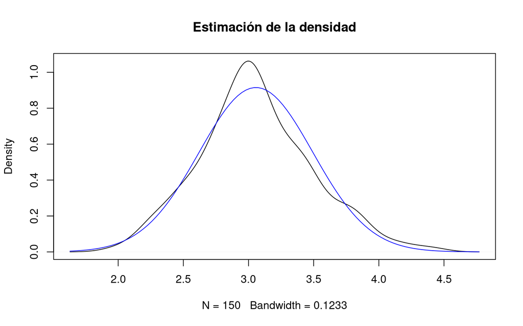

```r
plot(density(datos), main="Estimación de la densidad")
curve(dnorm(x,mu,sigma),col="blue",add=T)
```

```r
#summary(density(datos)[])
```

### Q-Q-plot

Este tipo de gráfico compara los **cuantiles observados de la muestra** con los **cuantiles teóricos de la distribución teórica**.

Este gráfico se puede hacer en `R` usando la función `qqPlot()` del paquete `car`.

```r
library(car)
qqPlot(
  x, # vector de datos de la muestra
  distribution="norm", # distribución teórica "t", "binom", "poisson", etc
  parameters..., # mean=mean(data), sd=sd(data), df=n-1, n=lentgh(data), p=x/n, etc
  id=FALSE, #
  grid=FALSE,
  line=none
)
```

#### Ejemplo

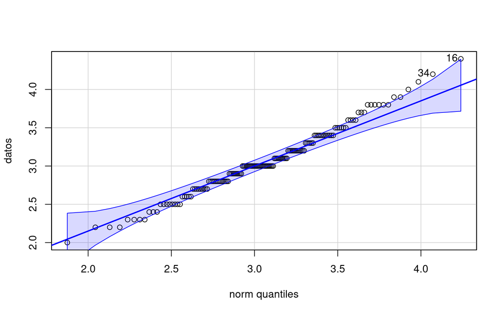

```
## [1] 16 34
```

```r
library(car)
qqPlot(datos, distribution="norm", mean=mu, sd=sigma)
```

Se observa que la mayoría de los valores de la muestra caen dentro de la franja del $95\%$ de confianza. Según esta prueba gráfica, “parece” que la distribución es normal, aunque se tienen dudas.

## Contraste $\chi^2$ de Pearson

Suponiendo que se tienen los valores de una muestra de tamaño $n$ de la v.a. $X$ que da los valores de la población $x_1,\ x_2,\ \dots,\ x_n$.

Luego, se clasifican los valores $x_i$, $i=1,\dots,n$ en $k$ clases.

Sean $n_1,n_2,\dots,n_k$, el número de valores de la muestra que están en cada una de las clases: $n_1$ sería el número de valores de la muestra que están en la clase $1$, $n_2$, el número de valores de la muestra que están en la clase $2$ y así sucesivamente hasta $n_k$.

Se obtendría lo que se conoce como **tabla de frecuencias empíricas**

| Clases | Clase $1$ | Clase $2$ | $\cdots$ | Clase $k$ | Total |
| --- | --- | --- | --- | --- | --- |
| Fracuencias empíricas | $n_1$ | $n_2$ | $\cdots$ | $n_k$ | $n$ |

El siguiente paso es obtener la tabla de la función de probabilidad de la variable discreta $X_k$ de valores $\{1,2,\dots,k\}$ y con función de probabilidad $p_i=P(X_k=i)=P(X_0\in\text{Clase }i),\ i=1,2,\dots,k$.

Esta función de probabilidad tiene que hallarse a partir del conocimiento de $X_0$. Si se desconocen los parámetros de los que depende $X_0$, se tendrán que estimar con técnicas de **estimación puntual**.

La tabla de la función de probabilidad $X_k$ quedaría de la siguiente forma

| $X_k$ | $1$ | $2$ | $\cdots$ | $k$ | Total |
| --- | --- | --- | --- | --- | --- |
| $P(X_k=i)$ | $P(X_k=1)$ | $P(X_k=2)$ | $\cdots$ | $P(X_k=k)$ | $1$ |

Multiplicando la tabla anterior por $n$, se obtiene la siguiente **tabla de frecuencias teóricas**

| Clases | Clase $1$ | Clase $2$ | $\cdots$ | Clase $k$ | Total |
| --- | --- | --- | --- | --- | --- |
| Frecuencias teóricas | $e_1$ | $e_2$ | $\cdots$ | $e_k$ | $n$ |

Donde $e_i=n\cdot{P}(X_k=i)$ es la **frecuencia teórica** de la clase $i$-ésima. ($e$ de “esperada”).

## Contraste

El **test $\chi^2$** o **test de bondad de ajuste** se basa en que, si la hipótesis nula es cierta, las **frecuencias empírias** y las **frecuencias teóricas** son “parecidas”.

Más concretamente, si la hipótesis nula es cierta, el estadístico siguiente

$$\chi^2=\sum_{i=1}^{k}{\frac{(\text{frec. empíricas}_i-\text{frec. teóricas}_i)^2}{\text{frec. teóricas}_i}}=\sum_{i=1}^{k}{\frac{(n_i-e_i)^2}{e_i}}$$

Sigue aproximadamente una distribución $\chi^2_{k-1}$ grados de libertad.

Sea $\chi_0$ el valor del estadístico de contraste anterior para nuestra muestra. El p-value del contraste vale

$$p=P(\chi^2_{k-1}>\chi_0)$$

- Si $p<0.05$, se rechaza $H_0$.
- Si $p>0.1$, no se tiene evidencia suficiente para rechazar $H_0$

## Condiciones del test

El test de **bondad de ajuste** está basado en el **estadístico $\chi^2$** que recordemos sigue aproximadamente una distribución $\chi^2_{k-1}$ grados de libertad

Al estar basado en un **Teorema Límite**, para que dicha aproximación sea efectiva, las condiciones siguientes se tienen que verificar:

- el tamaño de la muestra debe ser grande: $n\geq25$ o mejor $n\geq30$
- las clases deben cubrir todos los resultados posibles (en la práctica $n=\sum_{i=1}^{k}{n_i}=\sum_{i=1}^{k}{e_i}$)
- las **frecuencias teóricas** tienen que ser mayores o iguales que $5$, para todo $i=1,2,\dots,k$.

## Cálculo en `R`

Este test se puede hacer usando la función `chisq.test()` del paquete `stats` en `R`

```r
chisq.test(
  x, # vector (o tabla, calculada con table()) de frecuencias absolutas observadas
  p, # vector de probabilidades teóricas
  rescale.p # convierte lo valores de e_i a probabilidades
)
```

## Cálculo en `python`

```python
from scipy.stats import chisquare
chisquare(
  f_obs, # (Frequency observed) vector de frecuencias observadas
  f_exp # (Frequency expected) vector de frecuencias esperadas
)
```

También puede revisar la función `chi2_contingency()` del paquete `scipy.tats`.

## Ejemplo en `R`

```r
set.seed(2020)
muestra.flores = sample(iris$Species, 10)
chisq.test(table(muestra.flores), simulate.p.value = T)
##
##  Chi-squared test for given probabilities with simulated p-value (based
##  on 2000 replicates)
##
## data:  table(muestra.flores)
## X-squared = 0.8, df = NA, p-value = 0.7631
```

## Test $\chi^2$ de Pearson con parámetros poblacionales desconocidos

Cuando la v.a. $X_0$ de la población de contraste dependa de algunos parámetros desconocidos, se necesita conocer sus valores para poder calcular las frecuencias esperadas $e_i$.

La manera de resolver este inconveniente, es estimar dichos parámetros usando el [**estimador máximo verosímil**](https://joanby.github.io/bookdown-estadistica-inferencial/estimaci%C3%B3n-puntual.html#estimadores-m%C3%A1ximo-veros%C3%ADmiles) correspondiente.

Una vez estimados los parámetros de los que depende la v.a. de la población $X_0$, se puede realizar el **test de bondad de ajuste**, pero los grados de libertad de la distribución $\chi^2$ disminuyen, ahora serían $k-1-\text{número de parámetros estimados}$.

Algunos estimadores de **m+aximo verosímiles**

Poisson: $\widehat{\lambda}=\overline{X}$ Exponencial: $\widehat{\lambda}=\frac{1}{\overline{X}}$

## Ejemplo

El siguiente ejemplo muestra una prueba de bondad de ajuste para una variable $\text{Po}(\lambda)$.

```r
merge.class = TRUE
n = 576
lambdagorro = (0*299+1*211+2*93+3*35+4*7+5*1)/n
n.parametros = 1
df = data.frame(
  desde = c(0  , 1  , 2  , 3  , 4  , 5  ),
  hasta = c(0  , 1  , 2  , 3  , 4  , 5  ),
  o_i =   c(229, 211, 93 , 35 , 7  , 1  )
)
df$p_i = dpois(df$hasta,lambdagorro)
df[nrow(df),]$p_i = 1-ppois(df[nrow(df),]$hasta-1,lambdagorro)
df$e_i = n*df$p_i
if (merge.class) {
  j = 1
  for (i in 1:nrow(df)) {
    n = nrow(df)
    if (df[j,]$e_i < 5) {
      if (j > 1) {
        if (j < n) {
          if (df[j-1,]$e_i < df[j+1,]$e_i) { j = j-1 }
        } else { j = j-1 }
      }
      df[j,]$hasta = df[j+1,]$hasta
      df[j,]$o_i = sum(df[j:(j+1),]$o_i)
      df[j,]$p_i = sum(df[j:(j+1),]$p_i)
      df[j,]$e_i = sum(df[j:(j+1),]$e_i)
      if (j+2 <= n) {
        df = rbind(df[1:j,],df[(j+2):n,])
      } else { df = df[1:j,] }
    } else { j = j+1 }
  }
  rownames(df) = 1:nrow(df)
}
df[nrow(df),]$hasta = Inf
df$chi_i = (df$o_i-df$e_i)^2/df$e_i
##
round(df, 2)
##   desde hasta o_i  p_i    e_i chi_i
## 1     0     0 229 0.40 227.53  0.01
## 2     1     1 211 0.37 211.34  0.00
## 3     2     2  93 0.17  98.15  0.27
## 4     3     3  35 0.05  30.39  0.70
## 5     4   Inf   8 0.01   8.60  0.04
##
(chi0 = sum((df$o_i-df$e_i)^2/df$e_i))
## [1] 1.022098
##
(p.value = 1-pchisq(chi0,nrow(df)-1-n.parametros))
## [1] 0.795905
##
sum(df$e_i)
## [1] 576
```

## Test de Kolmogorov-Smirnov (K-S)

Se puede usar con muestras pequeñas ($n\geq5$), y la muestra no puede contener valores repetidos (si los contiene, la distribución del estadístico de contraste bajo la hipótesis nula no es la que predice la teoría sino que solo se aproxima a ella, y por lo tanto, los p-values que se obtienen son aproximados).

El test K-S realiza un contraste en el que la hipótesis nula es que la muestra proviene de una **distribución continua completamente especificada**.

### Aplicación

Sean $x_1,x_2,\dots,x_n$, con todos los valores diferentes, y se quiere contrastar si esos valores han sido producidos por una variable $X$ con distribución $F_X$.

Para aplicar el test **K-S** se aplican los siguientes pasos:

1. Se ordena la muestra de menos a mayor: $x_{(1)}<x_{(2)}<\cdots<x_{(n)}$.
2. Se calcula la **función de ditribución muestral $F_n$** de esta muestra, definida de la siguiente forma:

$$F_n(x)=\left\{\begin{array}{ll}0&\text{si } x<x_{(1)}\\[2pt]\frac{k}{n}&\text{si } x_{(k)}\leq x<x_{(k+1)}\\[2pt]1&\text{si } x_{(n)}\leq x\end{array}\right.$$

Por ejemplo, para el caso de que los valores de la muestra sean:

$$x = \{6.75, 7.26, 7.58, 8.8, 9.27, 9.49, 9.63, 10.04, 10.59, 10.78\}$$

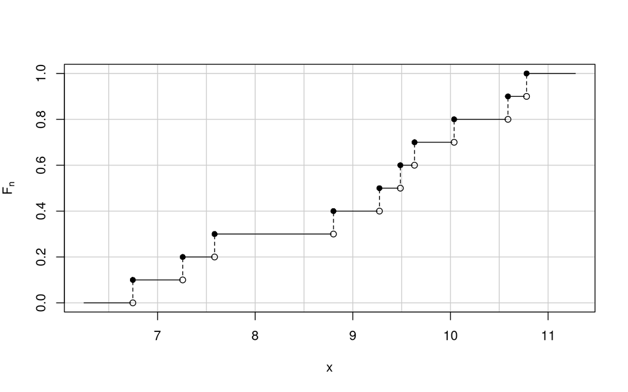

3. Se compara la **discrepancia** entre $F_n(x)$ con $F_X(x)$ con la siguiente fórmula:

$$D_n(x_{(i)})=\max\left\{\left|F_X(x_{(i)})-\frac{i-1}{n}\right|,\ \left|F_X(x_{(i)})-\frac{i}{n}\right|\right\},\quad\text{para }\ i=1,2,\dots,n$$

4. Por último, se calcula la discrepancia máxima

$$D_n=\max\left\{D_n(x_{(i)})\ |\ i=1,2,\dots,n\right\}$$

Se busca el p-value en una tabla de distribución de Kolmogorov-Smirnov y se compara con $D_n$ para saber si se rechaza o no $H_0$.

### Cálculo en `R`

Usando la función `ks.test()` del paquete `stats` en `R` se puede hacer esta prueba

```r
ks.test(
  x, # muestra de una variable continua
  y, # nombre de la función de distribución que se va a constrastar. Ej "pnorm"
  params # parámetros de la distribución que se va a contrastar. Ej mean, sd
)
```

## Tests de normalidad

### Datos para ejemplos

```r
data = c(0.873, 0.121, 2.817, -0.945, -0.55, -1.436, 0.36, -1.478, -1.869, -1.637)
```

### Test de Kolmogorov-Smirnov-Lilliefors (K-S-L)

Para realizar esta prueba se estiman los parámetros de $\mu$ y $\sigma$ utilizando los **estimadores máximo verosímiles**, es decir, **media muestral** para $\mu$ y **desviación típica muestral** para $\sigma$.

Este método consiste en estimar dichos parámetros, calcular la **discrepancia máxima**, y para calcular el p-value, se usa ahora la **distribución de Lilliefors**, el contraste es más robusto.

Este test tiene un inconveniente: aunque es muy sensible a las diferencias entre la muestra y la distribución teórica alrededor de sus valores medios, le cuesta detectar diferencias prominentes en un extremo u otro de la distribución.

Su potencia se ve afectada por dicho inconveniente.

En `R` se puede usar la función `lillie.test()` del paquete `nortest`.

```r
library(nortest)
lillie.test(
  data # muestra de una variable continua
)
##
##  Lilliefors (Kolmogorov-Smirnov) normality test
##
## data:  data
## D = 0.16718, p-value = 0.5948
```

En `python` se puede usar la función `lilliefors()` del paquete `statsmodels.stats.diagnostic`.

```python
from statsmodels.stats.diagnostic import lilliefors
lilliefors(
  x, # muestra de una variable continua
  dist='norm' # la distribución de contraste que puede ser 'norm' o 'exp'
)
```

### Test de Anderson-Darling (A-D)

Este test resuelve el inconveniente del **test K-S-L**, y se puede hacer en `R` usando la función `ad.test()` del paquete `nortest`.

```r
library(nortest)
ad.test(
  data # muestra de una variable continua
)
##
##  Anderson-Darling normality test
##
## data:  data
## A = 0.43791, p-value = 0.2328
```

Un inconveniente común de los **tests K-S-L y A-D** es que, si bien pueden usarse con muestras pequeñas (más de 5 elementos), se comportan mal con muestras grandes, de varios miles de elementos.

En muestras grandes, cualquier pequeña divergencia de la normalidad se magnifica y en estos dos tests aumenta la probabilidad de errores tipo I.

En `python` se puede realizar este test usando la función `anderson` del paquete `scipy.stats`

```python
from scipy.stats import anderson
result = anderson(r.data) # data es el vector de datos
result
## AndersonResult(statistic=0.43790621884128633, critical_values=array([0.501, 0.57 , 0.684, 0.798, 0.95 ]), significance_level=array([15. , 10. ,  5. ,  2.5,  1. ]))
for i in range(len(result.critical_values)):
  cv, sl = result.critical_values[i], result.significance_level[i]
  if result.statistic < cv:
    print("Probablemente Gaussiana a un nivel de significancia del %.3f" % (sl/100))
  else:
    print("Probablemente NO Gaussiana a un nivel de significancia del %.3f" % (sl/100))
## Probablemente Gaussiana a un nivel de significancia del 0.150
## Probablemente Gaussiana a un nivel de significancia del 0.100
## Probablemente Gaussiana a un nivel de significancia del 0.050
## Probablemente Gaussiana a un nivel de significancia del 0.025
## Probablemente Gaussiana a un nivel de significancia del 0.010
```

### Test de Shapiro-Wilks (S-W)

Este test resuelve el problema de los **tests de K-S-L y A-D**, está implementado en la función `shapiro.test()` del paquete `stats` en `R`.

```r
shapiro.test(
  data # muestra de una variable continua
)
##
##  Shapiro-Wilk normality test
##
## data:  data
## W = 0.8887, p-value = 0.164
```

Si la muestra tiene empates (valores repetidos), los p-values de los contrastes realizados con los tests **K-S-L**, **A-D** y **S-W** se pueden ver afectados hasta el punto de que, si hay muchos empates, su significado no tenga ningún sentido. Aunque el test menos afectado por los empates es el test de **S-W**

En `python` se puede realizar este test usando la función `shapiro` del paquete `scipy.stats`

```python
from scipy.stats import shapiro
stat, pv = shapiro(r.data) # data es el vector de datos
[stat, pv]
## [0.8887019157409668, 0.16395507752895355]
```

### Test omnibus de D’Agostino-Pearson ($K^2$)

Este test no es sensible a los empates (valores repetidos) como los tests **K-S-L**, **A-D** y **S-W**. Y lo que hace es cuantificar lo diferentes que son la asimetría y la curtosis de la muestra respecto de los esperados en una distribución normal, y resume esta discrepancia en un p-value con el significado usual.

Para poder realizar este test, se requiere que la muestra sea grande ($n\geq20$).

Este test se puede hacer en `R` usando la función `dagoTest` del paquete `fBasics`.

```r
library(fBasics)
dagoTest(
  x # muestra de una variable continua
)
```

En `python` se puede realizar este test usando la función `normaltest` del paquete `scipy.stats`

```python
from scipy.stats import normaltest
stat, pv = normaltest(r.data) # data es el vector de datos
## /home/andresaldana/anaconda3/lib/python3.8/site-packages/scipy/stats/stats.py:1603: UserWarning: kurtosistest only valid for n>=20 ... continuing anyway, n=10
##   warnings.warn("kurtosistest only valid for n>=20 ... continuing "
[stat, pv]
## [4.303501827712826, 0.11628038249613654]
```

# Contrastes de Independencia y Homogeneidad

## Tablas de contingencia

Teniendo una muestra de $n$ individuos clasificados por dos criterios $X$ y $Y$. Sean $x_1,x_2,\dots,x_I$ los distintos **niveles** del criterio $X$ y $y_1,y_2,\dots,y_J$, los distintos **niveles** del criterio $Y$.

Se define $n_{ij}$ como el número de individuos clasificados en el nivel $x_i$ según el criterio $X$ y clasificados en el nivel $y_j$ según el criterio $Y$. A partir de dicho valores se construye la **tabla de contingencia**:

| $X\text{\\}Y$ | $y_1$ | $\ldots$ | $y_j$ | $\ldots$ | $y_J$ | $n_{i \bullet}$ |
| --- | --- | --- | --- | --- | --- | --- |
| $x_1$ | $n_{11}$ | $\ldots$ | $n_{1j}$ | $\ldots$ | $n_{1J}$ | $n_{1\bullet}$ |
| $\vdots$ | $\vdots$ | $\vdots$ | $\vdots$ | $\vdots$ | $\vdots$ | $\vdots$ |
| $x_i$ | $n_{i1}$ | $\ldots$ | $n_{ij}$ | $\ldots$ | $n_{iJ}$ | $n_{i \bullet}$ |
| $\vdots$ | $\vdots$ | $\vdots$ | $\vdots$ | $\vdots$ | $\vdots$ | $\vdots$ |
| $x_I$ | $n_{I1}$ | $\ldots$ | $n_{Ij}$ | $\ldots$ | $n_{IJ}$ | $n_{I \bullet}$ |
| $n_{\bullet j}$ | $n_{\bullet 1}$ | $\ldots$ | $n_{\bullet j}$ | $\ldots$ | $n_{\bullet J}$ | $n$ |

Donde $n_{i\bullet}$ es el número total de individuos clasificados en el nivel $x_i$ según el criterio $X$, y $n_{\bullet j}$ es el número total de individuos clasificados en el nivel $y_j$ según el criterio $Y$.

El contraste que se plantea es el siguiente:

$$\left\{
\begin{array}{ll}
H_0 :&\text{Los criterios de clasificación } X \text{ y } Y \text{ son independientes.} \\[2pt]
H_1 :&\text{Los criterios de clasificación } X \text{ y } Y \text{ no son independientes.}
\end{array}
\right.$$

Para poder realizar el contraste anterior, se plantea como un contraste de **bondad de ajuste**.

Se define una variable “modelo” y, a partir de los datos empíricos, se contrasta si dichos datos siguen la variable “modelo” usando el test de la $\chi^2$ de la bondad de ajuste.

La variable “modelo” será una v.a. discreta **bidimensional** $(X,Y)$ con dominio $\{(x_1,y_1), (x_2,y_2),\dots,(x_I,y_J)\}$, o, si se quiere $\{(x_i,y_j)\ |\ i=1,2,\dots,I,\ j=1,2,\dots,J\}$. Sería una variable con $I\cdot J$ valores.

Para calcular la función de probabilidad de la variable $(X,Y)$, hay que suponer que la hipótesis nula $H_0$ es cierta o que los criterios $X$ y $Y$ son **independientes**. Por tanto:

$$P((X,Y)=(x_i,y_j))=
P(X=x_i)\cdot P(Y=y_j)=
\frac{n_{i\bullet}}{n}\cdot\frac{n_{\bullet j}}{n}=
\frac{n_{i\bullet}\cdot n_{\bullet j}}{n^2}$$

$i=1,2,\dots,I,\ j=1,2,\dots,J$

Los valores $n_ij$ serían los **valores empíricos** con los que hay que contrastar si siguen la distribución de la variable $(X,Y)$.

El estadístico $\chi^2$ de contraste es el siguiente:

$$\chi^2=
\sum_{i=1}^{I}{\sum_{j=1}^{J}{\frac{\left(n_{ij}-n\cdot P\left((X,Y)=(x_i,y_j)\right)\right)^2}{n\cdot P\left((X,Y)=(x_i,y_j)\right)}}}=
\sum_{i=1}^{I}{\sum_{j=1}^{J}{\frac{\left(n_{ij}-\frac{n_{i\bullet}\cdot n_{\bullet j}}{n}\right)^2}{\frac{n_{i\bullet}\cdot n_{\bullet j}}{n}}}}$$

donde las frecuencias $n_{ij}$ serían las **frecuencias observadas** y $\frac{x_{i\bullet}\cdot y_{\bullet j}}{n}$ serían las **frecuencias esperadas**.

Si $n$ es grande ($n\geq30$) y cada frecuencia esperada $\frac{x_{i\bullet}\cdot y_{\bullet j}}{n}$ es $\geq5$, este estadístico sigue aproximadamente una ley $\chi^2$ con $(I-1)\cdot(J-1)$ **grados de libertad**.

Entonces, el p-value es $P\left(\chi^1_{(I-1)\cdot(J-1)}\geq\chi_0\right)$

Este contraste se puede hacer en `R` usando la función `chisq.test()` del paquete `stats`.

```r
chisq.test(
  x, # tabla de contingencia, frecuencias observadas
  correct = TRUE # si TRUE, aplica la corrección por continuidad solo para tablas 2X2 (Corrección de Yates)
)
```

Nota: si algunas frecuencias absolutas esperadas son inferiores a $5$, la aproximación del p-value por una distribución $\chi^2$ podría no ser adecuada. Si se da esta situación, lo mejor es recurrir a simular el p-value usando el parámetro `simulate.p.value=TRUE`.

```r
## Densidades del paquete stats
dbeta()
dbinom()
dcauchy()
dchisq()
#density()
dexp()
df()
dgamma()
dgeom()
dhyper()
dlnorm()
dlogis()
#dmultinom()
dnbinom()
dnorm()
dpois()
dsignrank()
dt()
dunif()
dweibull()
dwilcox()
```

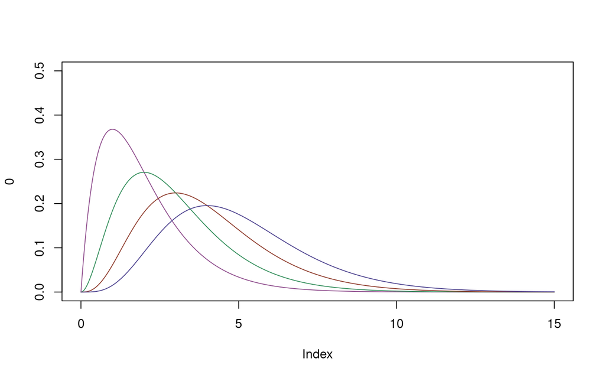

```r
x = seq(0,15,by=0.01)
imin = 2; imax = 5;
jmin = 2; jmax = 5;
cols = c("orchid","seagreen","tomato","slateblue")
plot(0, type='n', xlim=c(min(x),max(x)), ylim=c(0,0.5))
for (i in imin:imax) {
  #j = i
  for (j in jmin:jmax) {
    #lines(x, dbeta(x,i,j), col=paste(cols[i-1],j-1,sep=''))
  }
  lines(x, dgamma(x,i), col=paste(cols[i-1],j-1,sep=''))
}
```

```r
#plot(rep(x,36),dbeta(x,0:5,0:5),type='l')
```